# Time Series Analysis Assignment 2

Debangshu Bhattacharya (MDS201910)

03/10/2020

**Dataset used** The data I have used is the dataset “UKNonDurables” which is publicly available. The dataset consists of quarterly consumption of Non Durables in UK from 1st quarter of 1955 to 4th quarter of 1988. The dataset consists of 136 total observations. The documentation is found in the link https://vincentarelbundock.github.io/Rdatasets/doc/AER/UKNonDurables.html.

```r
library(tseries)
library(forecast)
library(dplyr)
library(moments)
```

```r
#Reading the data
data = read.table('UKNonDurables.csv',sep=',',header=T,stringsAsFactors = F)
head(data)
```

```
##   X    time value
## 1 1 1955.00 24030
## 2 2 1955.25 25620
## 3 3 1955.50 26209
## 4 4 1955.75 27167
## 5 5 1956.00 24620
## 6 6 1956.25 25972
```

**Step 1: Preparing the dataset**

```r
#Only keeping two columns : Time and Value
data = data[, c('time','value')]
head(data)
```

```
##      time value
## 1 1955.00 24030
## 2 1955.25 25620
## 3 1955.50 26209
## 4 1955.75 27167
## 5 1956.00 24620
## 6 1956.25 25972
```

```r
#Ordering data based on time
data = data[order(data$time),]

#Check for missing data
paste("Number of Missing values is", sum(is.na(data)))
```

```
## [1] "Number of Missing values is 0"
```

```r
#So there are no missing values in the dataset

#Cleaning data
start_date = data$time[1]
value = ts(data$value, start = start_date,freq =4)
value = tsclean(value)
data$value = value

#Dividing data into train and test sets where test set contains the last 6 observations
tm = data$time

period<- 6
n = length(value)
m = n - period


#Split data into train data and test data with test data having last 6 observations

train_lim = length(data$value) - period

train_data = data[1:train_lim,]
test_data = data[(train_lim+1):length(data$value),]
```

**Step 2 : Plot of the total data**

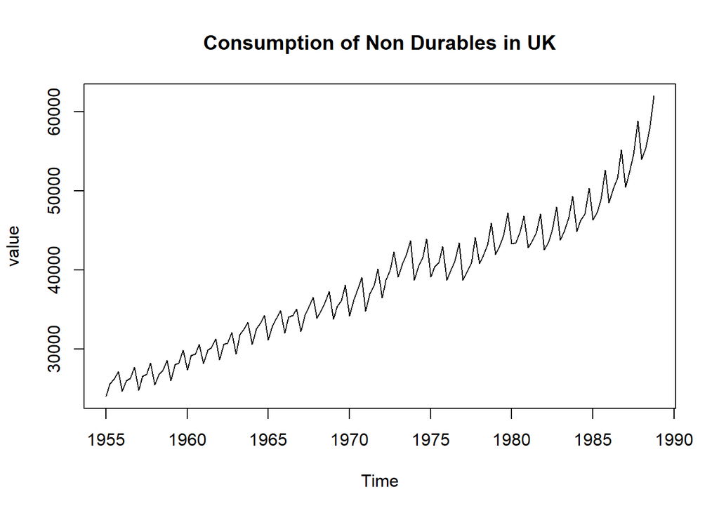

```r
#Time series plot of the whole data
ts.plot(value,main = "Consumption of Non Durables in UK")
```

**Step 3: Descriptive statistics of the data**

```r
value = ts(train_data$value, start = start_date, frequency = 4)
descriptive_stats = list('Mean' = mean(value),'Median' = median(value),'Minimum' = min(value),
                         'Maximum' = max(value), 'Standard Deviation' = sd(value) )
descriptive_stats$skewness = skewness(value)
descriptive_stats$kurtosis = kurtosis(value)

f <-function(x,mean1,sd1)
{
  #print (paste (mean1,sd1))
  count = 0
  for (i in c(1:length(x)))
  {
    if ((x[i]>=(mean1-3*sd1)) && (x[i]<=(mean1+3*sd1)))
      count = count+1
  }

  return ((count*100)/(length(x)))
}
descriptive_stats$perct_within_3sd = f(value,descriptive_stats$Mean,descriptive_stats$`Standard Deviation`)

str(descriptive_stats)
```

```
## List of 8
##  $ Mean              : num 37513
##  $ Median            : num 37747
##  $ Minimum           : num 24030
##  $ Maximum           : num 55152
##  $ Standard Deviation: num 7534
##  $ skewness          : num 0.0895
##  $ kurtosis          : num 2.05
##  $ perct_within_3sd  : num 100
```

So, the descriptive statistics of the train dataset can be seen from above. Note, that the data has a wide span of values and a high standard deviation of 7534.

**Step 4: Testing for stationarity/Coming up with Transformations to make it stationary** First, let’s check for the stationarity of the data using the three tests(ADF, KPSS and PP).

```r
adf.test(value)
```

```
##
##  Augmented Dickey-Fuller Test
##
## data:  value
## Dickey-Fuller = -3.1302, Lag order = 5, p-value = 0.1066
## alternative hypothesis: stationary
```

```r
kpss.test(value)
```

```
##
##  KPSS Test for Level Stationarity
##
## data:  value
## KPSS Level = 2.6633, Truncation lag parameter = 4, p-value = 0.01
```

```r
pp.test(value)
```

```
##
##  Phillips-Perron Unit Root Test
##
## data:  value
## Dickey-Fuller Z(alpha) = -139.63, Truncation lag parameter = 4, p-value
## = 0.01
## alternative hypothesis: stationary
```

Although, the PP test says that the data is stationary with a 5% level of significance, we cannot say that the data is stationary as the other two tests reject stationarity.

**Step 5: Coming up with the transformation of data** We have already seen that the values of the data span a wide range. So, a log transformation may be a good idea. Anyways we plot the time series of first difference of the data as follows:

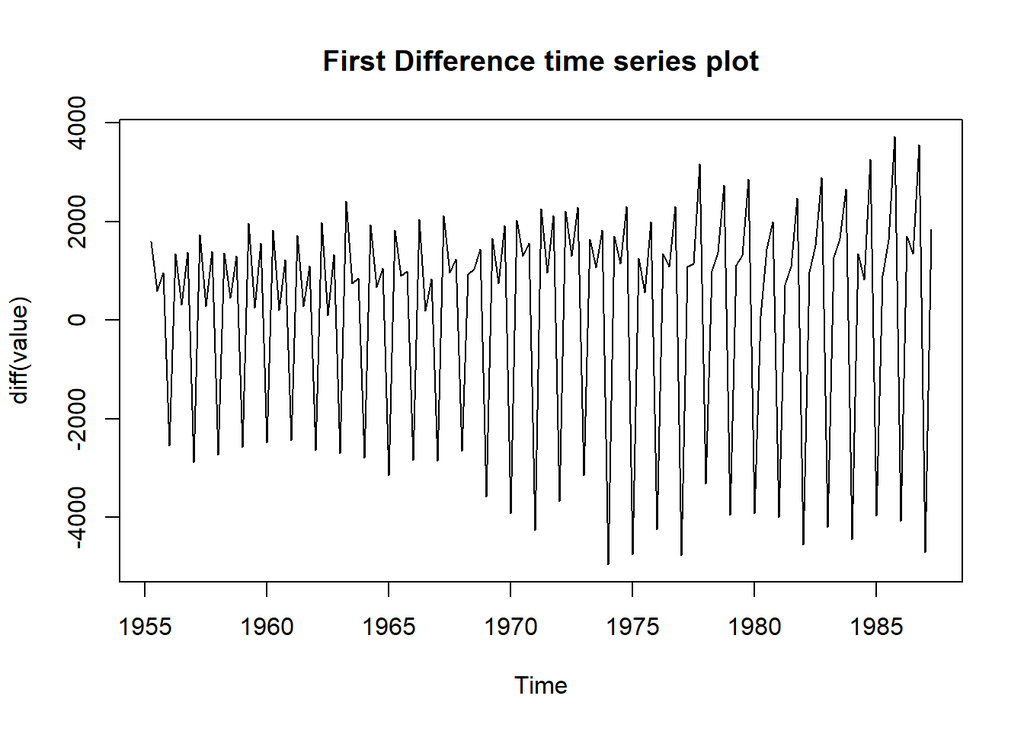

```r
ts.plot(diff(value),main = "First Difference time series plot")
```

We see that the variance does not seem constant. We also had seen that the range of the data is very large.So, we take the log transform of the data and proceed.

```r
value = log(value)

adf = adf.test(value)
print (adf)
```

```
##
##  Augmented Dickey-Fuller Test
##
## data:  value
## Dickey-Fuller = -2.8073, Lag order = 5, p-value = 0.2409
## alternative hypothesis: stationary
```

```r
kpss = kpss.test(value)
print (kpss)
```

```
##
##  KPSS Test for Level Stationarity
##
## data:  value
## KPSS Level = 2.6535, Truncation lag parameter = 4, p-value = 0.01
```

```r
pp = pp.test(value)
print (pp)
```

```
##
##  Phillips-Perron Unit Root Test
##
## data:  value
## Dickey-Fuller Z(alpha) = -136.44, Truncation lag parameter = 4, p-value
## = 0.01
## alternative hypothesis: stationary
```

The log of the data is not stationary but let’s see the first difference of the log of the values.

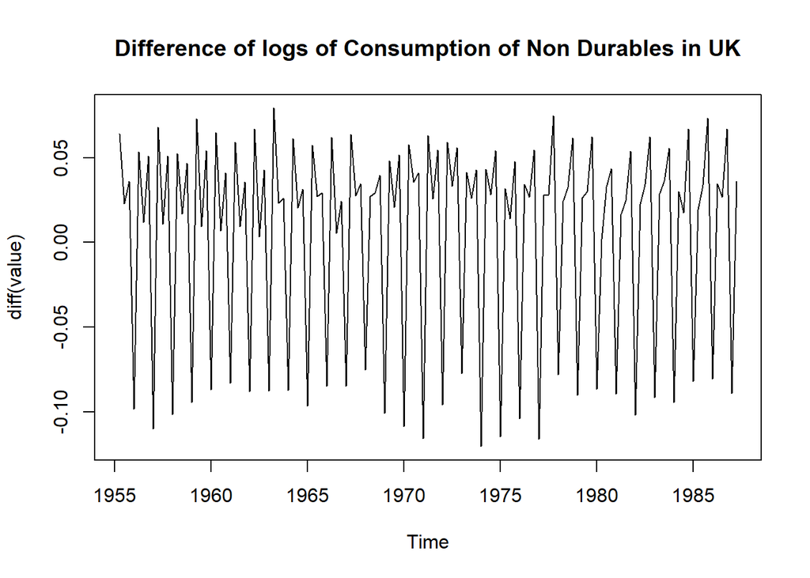

```r
ts.plot(diff(value),main = "Difference of logs of Consumption of Non Durables in UK")
```

This look’s much better than the first difference of the values. Let’s do the stationarity tests on these.

```r
adf = adf.test(diff(value))
print (adf)
```

```
##
##  Augmented Dickey-Fuller Test
##
## data:  diff(value)
## Dickey-Fuller = -4.1495, Lag order = 5, p-value = 0.01
## alternative hypothesis: stationary
```

```r
kpss = kpss.test(diff(value))
print (kpss)
```

```
##
##  KPSS Test for Level Stationarity
##
## data:  diff(value)
## KPSS Level = 0.039654, Truncation lag parameter = 4, p-value = 0.1
```

```r
pp = pp.test(diff(value))
print (pp)
```

```
##
##  Phillips-Perron Unit Root Test
##
## data:  diff(value)
## Dickey-Fuller Z(alpha) = -151.78, Truncation lag parameter = 4, p-value
## = 0.01
## alternative hypothesis: stationary
```

**Step 6: Fitting ARIMA models** a) AIC model

```r
#Fitting model which has minimum AIC
d = 1
model_fit = auto.arima(value,seasonal = F,d=d,max.p = 5, max.q = 5, ic = "aic")
model_fit
```

```
## Series: value
## ARIMA(2,1,2) with drift
##
## Coefficients:
##           ar1      ar2      ma1     ma2   drift
##       -0.0399  -0.6266  -1.1314  0.7224  0.0057
## s.e.   0.0822   0.0823   0.0903  0.0583  0.0010
##
## sigma^2 estimated as 0.001157:  log likelihood=254
## AIC=-495.99   AICc=-495.3   BIC=-478.83
```

b)BIC model

```r
model_fit = auto.arima(value,seasonal = F,d=d,max.p = 5, max.q = 5, ic = "bic")
model_fit
```

```
## Series: value
## ARIMA(2,1,2) with drift
##
## Coefficients:
##           ar1      ar2      ma1     ma2   drift
##       -0.0399  -0.6266  -1.1314  0.7224  0.0057
## s.e.   0.0822   0.0823   0.0903  0.0583  0.0010
##
## sigma^2 estimated as 0.001157:  log likelihood=254
## AIC=-495.99   AICc=-495.3   BIC=-478.83
```

So, the same model is selected for both AIC and BIC. We are going to proceed with this model.

**Step 7: Forecasting and evaluating the model**

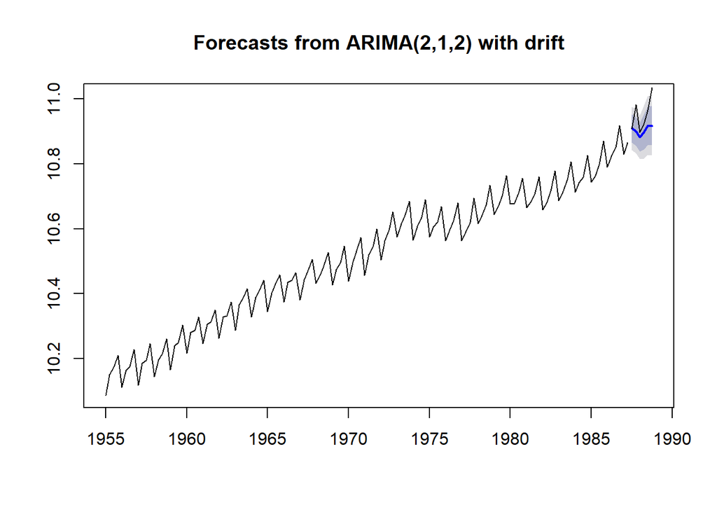

```r
plot(forecast(model_fit,h=period),type='l')
lines(test_data$time, log(test_data$value) )
```

We do that conversion and print the mse as follows:

```r
forecasted_values = forecast(model_fit,h = period)
forecasted_values = as.numeric(forecasted_values$mean)

forecasted_values = lapply(forecasted_values,exp)
forecasted_values = as.numeric(forecasted_values)

true_values = data$value[(m+1):(m+period)]

mse = mean((true_values-forecasted_values)^2)

mse
```

```
## [1] 13175977
```

The value looks quite big. But as we saw from the descriptive stats of the data, the training data itself spans over a wide range and has a variance of 56761482 as shown below:

```r
descriptive_stats$`Standard Deviation`^2
```

```
## [1] 56761482
```

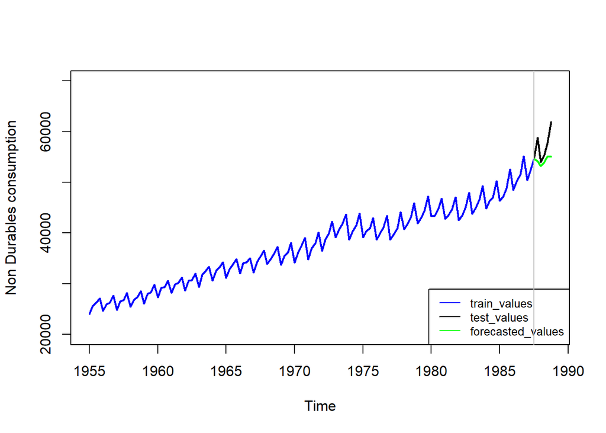

```r
plot(NULL,xlim = c(tm[1],tm[n]),ylim = c(20000,70000),ylab = 'Non Durables consumption',xlab='Time')
points(data$time, data$value,type='l',lwd=2,col='blue')
points(test_data$time, test_data$value,type='l',lwd=2,col='black')
points(test_data$time, forecasted_values,type='l',lwd=2,col='green')
legend("bottomright",
       legend =  c("train_values","test_values","forecasted_values"),
       col = c("blue","black","green"),lty = 1,
       cex = 0.8)

abline(v=tm[m+1],col='grey')
```

The comparison of true value and forecasted value is shown below:

```r
data.frame("True_value"=true_values, "Forecasted_values" = forecasted_values)
```

```
##   True_value Forecasted_values
## 1      54633          54663.91
## 2      58802          54156.47
## 3      53990          53196.82
## 4      55477          54058.95
## 5      57850          55155.39
## 6      61978          55080.68
```